# RepatiProjectSnap

Mykala Repati

22 May, 2020

# Packages and Data

```r
library(tidyverse)
```

```r
snap <- read.csv("PoliticalAds.csv")
str(snap)
head(snap)
```

[output not shown]

I have downloaded the 2018 Political Advertisement data off of Snapchat’s website by downloading a .zip file and converting it to a .csv file, which can be read here. Using the following two graphs, I will attempt to look at how demographics relating to age, gender, and country influence general use and advertisement targetting.

```r
snap_sum1 <- snap %>%
group_by(CountryCode,AgeBracket) %>%
summarize(freq=n()) %>%
mutate(perc=freq/sum(freq)*100) %>%
ungroup()
snap_sum1
```

```
#R> # A tibble: 72 x 4
#R>    CountryCode AgeBracket  freq   perc
#R>    <fct>       <fct>      <int>  <dbl>
#R>  1 australia   ""             2  25
#R>  2 australia   "24-"          1  12.5
#R>  3 australia   "30+"          4  50
#R>  4 australia   "35++"         1  12.5
#R>  5 belgium     "17-24"        1 100
#R>  6 canada      ""            15  50
#R>  7 canada      "16-22"        1   3.33
#R>  8 canada      "16-25"        6  20
#R>  9 canada      "18-26"        1   3.33
#R> 10 canada      "24-"          1   3.33
#R> # … with 62 more rows
```

Here I am summarizing my data to use for my second plot. The code is compiling country and age information into a frquency, and then percentage so that I may see how many people fall in each specified category.

# Spent vs Views by Country and Gender

```
#R> `geom_smooth()` using formula 'y ~ x'
```

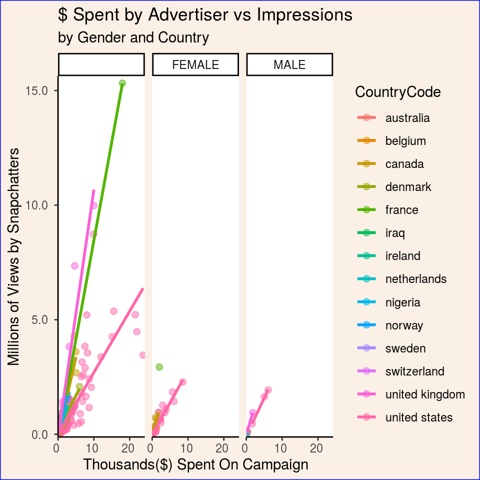

```r
p <- ggplot(data=snap,mapping=aes(x=Spend,y=Impressions,colour=CountryCode,fill=CountryCode)) +
geom_point(pch=21,alpha=0.5,size=2) +
scale_x_continuous(name="Thousands($) Spent On Campaign",breaks=seq(0,20000,10000),labels=scales::unit_format(unit="",scale=1/1000),expand=expansion(mult=c(0,0.02))) +
scale_y_continuous(name="Millions of Views by Snapchatters",labels=scales::unit_format(unit="",scale=1/1000000),expand=expansion(mult=c(0,0.02))) +
geom_smooth(method="lm",se=FALSE) +
theme_classic() +
theme(panel.grid.minor=element_blank()) +
facet_wrap(vars(Gender)) +
labs(title="$ Spent by Advertiser vs Impressions",subtitle="by Gender and Country") +
theme(plot.background=element_rect(fill="linen",color="blue"),legend.background=element_rect(fill="linen"))
p
```

This graph attempts to show how gender effects money spent on advertising and how well the advertisements are recieved. However, since a large portion of Snapchat’s users do not specify their gender, the majority of the data takes place in the unlabeled “other” gender box. As you can see, a scatterplot of all data points has been compiled, with a regression line or line of best fit over the top. The line, added with a smoother using geom_smooth, particularly helps outline the increased number of views in France compared to other countries.

# Age Bracket and Country

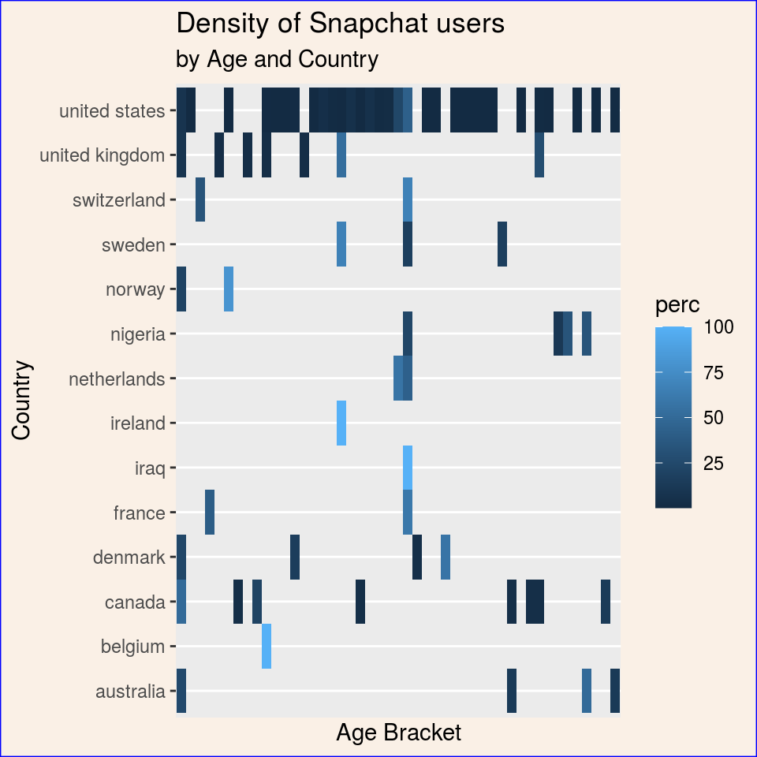

```r
p <- ggplot(data=snap_sum1,mapping=aes(x=AgeBracket,y=CountryCode,fill=perc)) +
geom_tile() +
scale_x_discrete(name="Age Bracket",breaks=seq(0,100,10)) +
scale_y_discrete(name="Country") +
labs(title="Age Distribution of Snapchatters",subtitle="by Country") +
labs(title="Density of Snapchat users",subtitle="by Age and Country") +
theme_grey() +
theme(plot.background=element_rect(fill="linen",color="blue"),legend.background=element_rect(fill="linen"))
p
```